# Jurisdição Constitucional

Continuação da disputa político-partidária por outros meios?

Gustavo Henrique Catisane Diniz

2024-09-05

# Objeto e objetivos

**Objeto**: Influxos da disputa político-partidária sobre o exercício da jurisdição constitucional pelo Supremo Tribunal Federal

**Objetivos**:

1. Considerando o peculiar desenho institucional brasileiro, que atribui ao Presidente da República e aos partidos políticos legitimidade para a propositura de ações de controle concentrado de constitucionalidade (ADI/ADC/ADPF), questiona-se se o exercício da jurisdição constitucional pelo Supremo Tribunal Federal espelharia, mesmo que parcialmente, a disputa político-partidária ocorrida no âmbito do Congresso Nacional.
2. Busca-se aferir se as ações de controle concentrado de constitucionalidade seriam instrumentos utilizados precipuamente pelos partidos políticos que compõem a Coalizão de Governo ou pelos partidos políticos da Oposição.
3. Também se almeja verificar se as ações de controle concentrado de constitucionalidade ajuizadas por partidos políticos que compõem, no momento em que decisão judicial é prolatada, a Coalização de Governo possuiriam maior probabilidade de êxito em suas postulações.
4. Objetiva-se, ainda, verificar se há uma diferença significtaiva entre o número de ações de controle concentrado de constitucionalidade ajuizadas por partidos políticos classificados ideologicamente como de Direita e o número de ações de controle concentrado de constitucionalidade ajuizadas pelos partidos políticos classificados ideologicamente como de Esquerda.
5. Por fim, busca-se aferir se Ministros do Supremo Tribunal Federal indicados por Presidentes da República classificados ideologicamente como de Esquerda ou de Direita teriam a propensão de decidir mais favoravelmente a partidos políticos que gravitam no mesmo campo ideológico.

# Justificativa

Considerando a proeminência alcançada pelo Supremo Tribunal Federal na definição e na efetivação do desenho institucional esboçado pela Constituição de 1988, acabando por se imiscuir em searas até então compreendidas como eminentemente políticas, afigura-se relevante - e mesmo necessária - a análise de se e como o exercício da jurisdição constitucional pela nossa Corte Suprema espelha, mesmo que parcialmente, as dinâmicas inerentes às disputas político-partidárias travadas no âmbito do Congresso Nacional.

[figure not shown]

# Metodolgia

Os dados foram extraídos do [Programa Corte Aberta do Supremo Tribunal Federal](https://transparencia.stf.jus.br/extensions/corte_aberta/corte_aberta.html) e do sítio eletrônico do [Banco de Dados Legislativos do CEBRAP](https://bancodedadoslegislativos.com.br/index.php).

Os dados foram trabalhados e combinados com a finalidade de se obter a listagem de todas as ações de controle concentrado de constitucionalidade ajuizadas, desde a promulgação da Constituição de 1988, pelos Presidentes da República e pelos partidos políticos. Os partidos políticos foram classificados como pertecentes à Coalizão de Governo ou à Oposição.

Os partidos políticos também foram classificados ideologicamente com base na classificação sugerida por Bolognesi, Ribeiro, Coldato, 2023.

Com base nesses dados, foi sugerido um *proxy* para a mensuração do posicionamneto ideológico dos Ministros do Supremo Tribunal Federal, consistente na diferença entre o número de decisões proferidas em processos de controle concentrado de constitucionalidade (ADC/ADI/ADPF) favoráveis a partidos políticos de Esquerda e o número de decisões favoráveis a partidos de Direita.

Tendo em vista que o número de processos ajuizados pelos partidos políticos de Direita é menor do que o número de processos ajuizados pelos partidos políticos de Esquerda (786 e 1341), foi atribuído o peso de 1,7 às decisões judiciais favorávei proferidas nos processos ajuizados pelos partidos de Direita. A fim de evitar valores negativos, a cada um dos valores foi adicionado 50 unidades. Desse modo, valores acima de 50 revelam posicionamento ideológico à Esquerda e valores abaixo de 50, posicionamento ideológico à Direita.

Desse modo, a cada um dos Ministro da Suprema Corte foi atribuída uma pontuação (número de decisões favoráveis à partidos de Esquerda - 1,7*número de decisões favoráveis a partidos de Direita)

Todos os Ministros que atuaram na Corte Suprema desde a promulgação da Constituição de 1988 foram ideologicamente classificados a partir da ideologia professada pelo Presidente da República responsável pela indicação.

A partir dessa classificação, foram criados dois grupos: Ministros de Direita e Ministros de Esquerda.

Decidiu-se então por testar se existiria uma diferença estatisticamente significante entre as médias das pontuações atribuídas a cada um dos grupos. Ou seja, se Ministros indicados por Presidentes de Direita ou de Esquerda tenderiam a votar mais favoravlemente a partidos que estivessem no mesmo campo ideológico.

Eis as hipóteses a serem testadas:

**Hipótese nula (H0)**: a média dos ’posicionamentos ideológicos” dos Ministros do STF indicados por Presidentes da República classificados ideologicamente como de Direita **não** diverge da média dos “posicionamentos ideológicos” dos Ministros do STF indicados por Presidentes da República ideologicamente classificados como de Esquerda.

**Hipótese alternativa (HA)**: a média dos “posicionamentos ideológicos” dos Ministros do STF indicados por Presidentes da República classificados ideologicamente como de Direita diverge da média dos “posicionamentos ideológicos” dos Ministros do STF indicados por Presidentes da República ideologicamente classificados como de Esquerda.

É pressuposto do referido teste a distribuição normal dos dados. Em um primeiro momento, aferiu-se, por intermédio do Teste de Shapiro-Wilk, que a distribuição das observações relativas ao grupo dos Ministros indicados por Presidentes de Direita não era normal. Após análise pormenorizada dos dados, verificou-se que a anormalidade da distribuição decorria da existência de uma observação extrema (“outlier”) - Ministro Ilmar Galvão. Optou-se por excluí-la, a fim de permitir a utilização do Teste-t.

# Coalizões de Governo (CEBRAP - Banco de Dados Legislativos)

| Presidente | Partidos_coalizao |
| --- | --- |
| Sarney | PMDB - PFL |
| Collor | PRN - PFL |
| Collor | PRN - PFL - PDS |
| Collor | PRN - PFL - PDS |
| Collor | PRN - PFL - PDS - PTB - PL |
| Itamar | PFL - PTB - PMDB - PSDB - PSB |
| Itamar | PFL - PTB - PMDB - PSDB - PP |
| Itamar | PFL - PMDB - PSDB - PP |
| FHC I | PSDB - PFL - PMDB - PTB |
| FHC I | PSDB - PFL - PMDB - PTB - PPB |
| FHC II | PSDB - PFL - PMDB - PPB |
| FHC II | PSDB - PMDB - PPB |
| Lula I | PT - PL - PCdoB - PSB - PTB - PDT - PPS - PV |
| Lula I | PT - PL - PCdoB - PSB - PTB - PPS - PV - PMDB |
| Lula I | PT - PL - PCdoB - PSB - PTB - PV - PMDB |
| Lula I | PT - PL - PCdoB - PSB - PTB - PMDB |
| Lula I | PT - PL - PCdoB - PSB - PTB - PMDB - PP |
| Lula II | PT - PR - PCdoB - PSB - PTB - PMDB - PP - PRB |
| Lula II | PT - PR - PCdoB - PSB - PTB - PMDB - PP - PDT - PRB |
| Lula II | PT - PR - PCdoB - PSB - PMDB - PP - PDT - PRB |
| Dilma I | PT - PR - PCdoB - PSB - PMDB - PDT - PP |
| Dilma I | PT - PR - PCdoB - PSB - PMDB - PDT - PP- PRB |
| Dilma I | PT - PR - PCdoB - PMDB - PDT - PP- PRB |
| Dilma II | PT - PMDB - PCdoB - PDT - PR - PRB - PP - PROS - PSD - PTB |
| Dilma II | PT - PMDB - PCdoB - PDT - PR - PRB - PP - PSD - PTB |
| Dilma II | PT-PMDB-PDT-PCdoB-PR-PP-PSD-PTB |
| Dilma II | PT-PCdoB-PDT-PR-PP-PSD-PTB |
| Dilma II | PT-PCdoB-PDT-PR-PSD-PTB |
| Temer | PMDB-PSDB-PR-PRB-PSD-PTB-DEM-PPS-PP |
| Temer | PMDB-PSDB-PR-PRB-PSD-PTB-DEM-PPS-PP |
| Temer | PMDB-DEM-PSDB-PR-PRB-PSD-PTB-PP |
| Bolsonaro | PSL |
| Bolsonaro | sem coalizão |

# Comparativo entre as ações de controle concentrado de constitucionalidade ajuizadas por partidos políticos da Coalização de Governo (incluídas as ações ajuizadas pelos Presidentes da República) e por partidos políticos da Oposição

### Número total de ações de controle concentrado de constitucionalidade ajuizadas por partidos políticos da Coalizão de Governo e da Oposição desde a promulgação da Constituição de 1988

| Posicionamento | Número | Proporção |
| --- | --- | --- |
| Governo | 408 | 19.14594 |
| Oposição | 1723 | 80.85406 |

# Número de ações de controle concentrado ajuizadas por partidos políticos da Coalizão de Governo e da Oposição em cada mandato presidencial

| Presidente | Governo | Oposição |
| --- | --- | --- |
| Bolsonaro | 17 | 679 |
| Collor | 0 | 45 |
| Dilma 1 | 34 | 79 |
| Dilma 2 | 41 | 80 |
| FHC 1 | 17 | 148 |
| FHC 2 | 19 | 303 |
| Itamar | 8 | 17 |
| Lula 1 | 73 | 93 |
| Lula 2 | 63 | 122 |
| Lula 3 | 88 | 78 |
| Sarney | 0 | 4 |
| Temer | 48 | 75 |

# Distribuição das ações de controle concentrado ajuizadas por partidos políticos da Coalizão de Governo e da Oposição em cada mandato presidencial

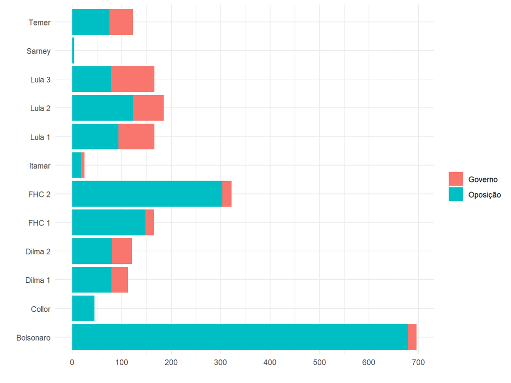

# Probabilidade de êxito das ações de controle concentrado de constitucionalidade ajuizadas por partidos políticos que compõem a Coalização de Governo no momento em que a decisão judicial é proferida

```
## # A tibble: 1 × 2
##     Não   Sim
##   <int> <int>
## 1   518   175
```

| Posicionamento | Dec_fav | Ações | Êxito |
| --- | --- | --- | --- |
| Oposição | 518 | 1723 | 30.06384 |
| Governo | 175 | 408 | 42.89216 |

# **Política judicial**: uma proposta de mensuração dos posicionamentos ideológicos dos Ministros do Supremo Tribunal Federal com base nas decisões proferidas em ações de controle concentrado de constitucionalidade ajuizadas por partidos políticos e pelos Presidentes da República desde a promulgação da Constituição de 1988

Classificação ideológica dos partidos políticos brasileiros (Bolognesi, Ribeiro, Coldato, 2023)

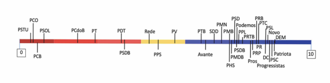

# Comparativo entre o número de ações de controle concentrado de constitucionalidade ajuizadas por partidos de Esquerda e de Direita (Classificação binária)

| Requerente | Número | Proporção |
| --- | --- | --- |
| Direita | 786 | 36.95346 |
| Esquerda | 1341 | 63.04654 |

Obs: Tendo em vista a inexistência de Ministros do Supremo Tribunal Federal indicados por Presidentes classificados ideologicamente como de Centro, decidiu-se por uma divisão binária ou dicotômica (Direita-Esquerda), utilizando-se a mediana da distribuição. Desse modo, REDE, PPS e PV foram classificados como partidos de Esquerda.

# Há diferença entre os posicionamentos ideológicos dos Ministros do Supremo Tribunal Federal indicados por Presidentes de Direita e de Esquerda? É possível aferir essa diferença utilizando como critério a diferença entre o número de decisões favoráveis a partidos de Esquerda e de Direita?

| Ministro | Presidente | Posicionamento_ideológico |
| --- | --- | --- |
| MIN. ALEXANDRE DE MORAES | Direita | 49.2 |
| MIN. ANDRÉ MENDONÇA | Direita | 52.5 |
| MIN. AYRES BRITTO | Esquerda | 59.3 |
| MIN. CARLOS VELLOSO | Direita | 50.6 |
| MIN. CELSO DE MELLO | Direita | 48.4 |
| MIN. CEZAR PELUSO | Esquerda | 42.5 |
| MIN. CRISTIANO ZANIN | Esquerda | 73.9 |
| MIN. CÁRMEN LÚCIA | Esquerda | 78.6 |
| MIN. CÉLIO BORJA | Direita | 51.0 |
| MIN. DIAS TOFFOLI | Esquerda | 60.6 |
| MIN. EDSON FACHIN | Esquerda | 58.6 |
| MIN. ELLEN GRACIE | Direita | 47.8 |
| MIN. EROS GRAU | Esquerda | 46.2 |
| MIN. FLÁVIO DINO | Esquerda | 50.6 |
| MIN. GILMAR MENDES | Direita | 45.8 |
| MIN. ILMAR GALVÃO | Direita | 17.8 |
| MIN. JOAQUIM BARBOSA | Esquerda | 49.5 |
| MIN. LUIZ FUX | Esquerda | 34.2 |
| MIN. LUÍS ROBERTO BARROSO | Esquerda | 76.5 |
| MIN. MARCO AURÉLIO | Direita | 53.7 |
| MIN. MAURÍCIO CORRÊA | Direita | 51.5 |
| MIN. MENEZES DIREITO | Esquerda | 53.0 |
| MIN. MOREIRA ALVES | Direita | 46.6 |
| MIN. NELSON JOBIM | Direita | 52.0 |
| MIN. NUNES MARQUES | Direita | 51.2 |
| MIN. NÉRI DA SILVEIRA | Direita | 46.6 |
| MIN. RICARDO LEWANDOWSKI | Esquerda | 61.2 |
| MIN. ROSA WEBER | Esquerda | 69.0 |
| MIN. SEPÚLVEDA PERTENCE | Direita | 48.9 |
| MIN. SYDNEY SANCHES | Direita | 54.6 |
| MIN. TEORI ZAVASCKI | Esquerda | 46.6 |

# Distribuição dos posicionamentos ideológicos dos Ministros do Supremo Tribunal Federal

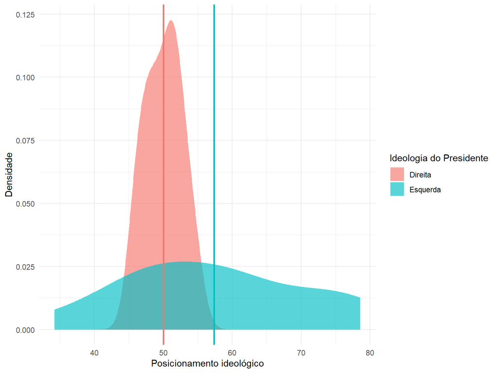

# Teste de normalidade da distribuição (Teste de Shapiro-Wilk)

```
## # A tibble: 2 × 4
##   Presidente variable                  statistic     p
##   <chr>      <chr>                         <dbl> <dbl>
## 1 Direita    Posicionamento_ideológico     0.967 0.809
## 2 Esquerda   Posicionamento_ideológico     0.966 0.796
```

A hipótese nula não foi rejeitada (H0 = os dados seguem a distribuição normal).

# Teste de hipótese - Teste-t para amostras independentes com variâncias iguais

É pressuposto do referido teste a distribuição normal dos dados. Em um primeiro momento, aferiu-se, por intermédio do Teste de Shapiro-Wilk, que a distribuição das observações relativas ao grupo dos Ministros indicados por Presidentes de Direita não era normal.

Após análise pormenorizada dos dados, verificou-se que a anormalidade da distribuição decorria da existência de uma observação extrema (“outlier”) - Ministro Ilmar Galvão.

Optou-se por excluí-la, a fim de permitir a utilização do Teste-t.

```
## # A tibble: 1 × 7
##   statistic  t_df p_value alternative estimate lower_ci upper_ci
##       <dbl> <dbl>   <dbl> <chr>          <dbl>    <dbl>    <dbl>
## 1     -2.13    28  0.0420 two.sided      -7.33    -14.4   -0.286
```

Anteriormente à exclusão da observação extrema (“outlier”), a divergência entre as médias dos posicionamentos ideológicos dos grupos era estatisticamente significante. Contudo,a distribuição dos dados do grupo “Direita” não era normal.

# Boxplot

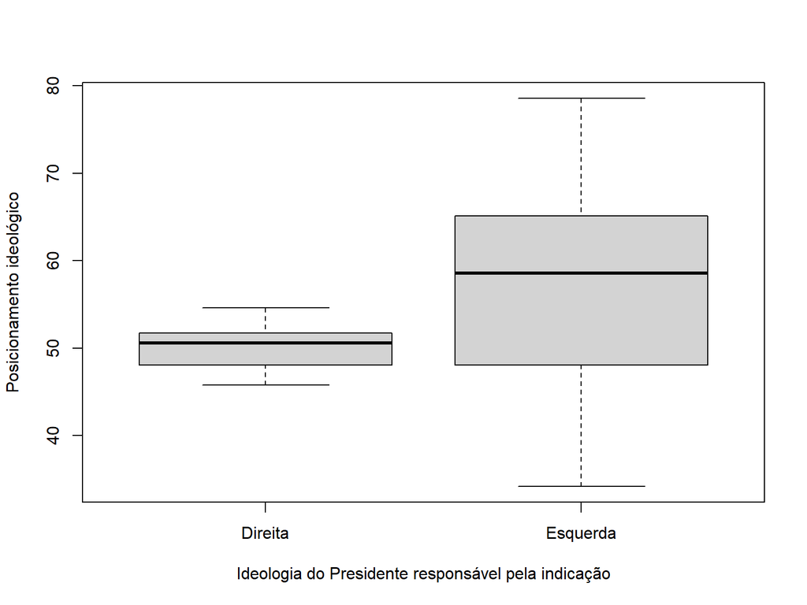

# Médias e intervalos de confiança

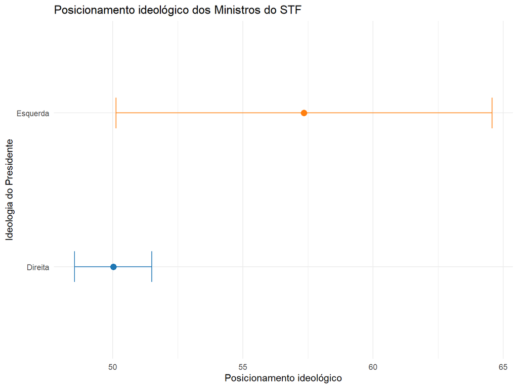

# Gráfico linear

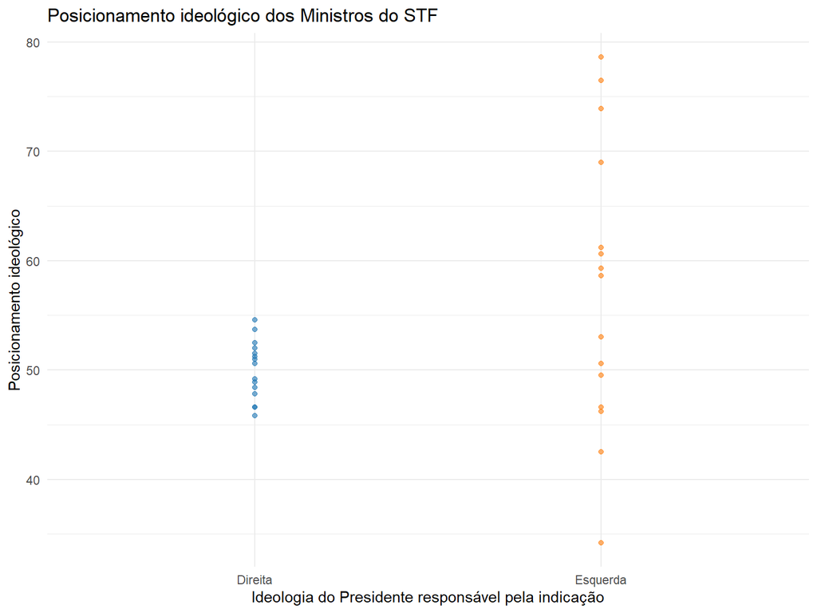

# Conclusões

[figure not shown]